# Taskscheduler and Crontab with R

Aritra Biswas

July 19, 2016

From the point of view of a data scientist this is important to explore a phenomena over time. While conducting an experiment with social networking sites websites I’ve found these beautiful tools which can run r scripts automatically after a per specified time by the user. Here is a tutorial explaining task scheduling process for Windows 10 and Linux Debian Jessie (This is the latest OS for Raspberry Pi).

Here we will observe two videos from the Times Now YouTube channel and try to understand the change in viewership and other related statistics over time. For this process, we will use the YouTube data API and R. We will download the data from the YouTube data API after a certain time interval and store them in an R friendly Object. After running this process for several hours we will try to understand the data pattern using statistical models. Here for demonstration purpose initially we will visualize the data using ggplot2. We also will try to predict the view count or any other variable using them as dependent variable.

**Note:** This is only for demonstration purpose. This model will not fit well in this case, since the data is not linear in nature. Other higher degree polynomials Of the dependent variable or any black box predictors can be taken under consideration for accuracy.

This process can be used with many more such application where running a script is essential after a interval of time.

### For windows:

Now go to **Control Panel-> Administrative Tools -> Task Scheduler**.

Select Create Basic Task, provide a name and a description of the task so that this can be easily recognized later. Click on next.

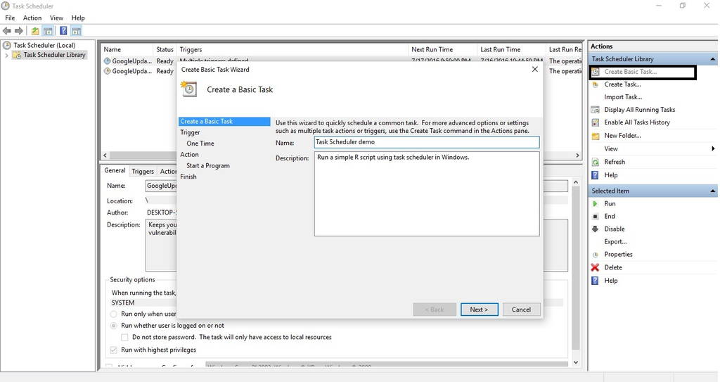

Select **One time** and click on next. This will create a one time job initially. Later on we will change the task so that it will be executed after a specified time. The time lag on which the script will be executed (i.e.once a day, week or month) will be specified later.

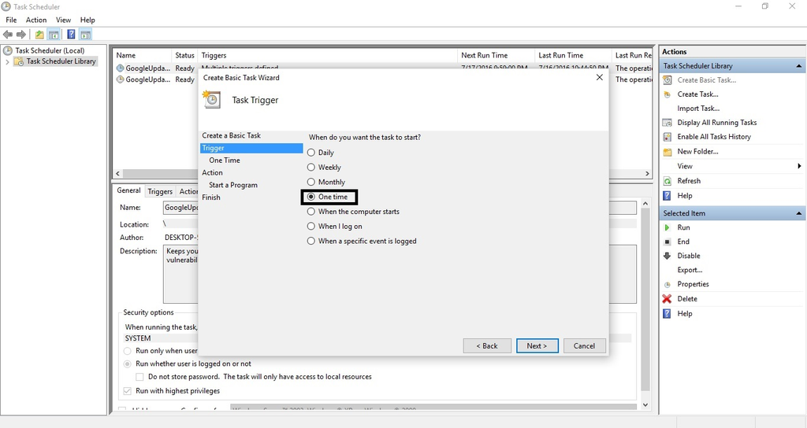

**Select the date and time** when the task will be executed for the first time. This is recommended to set the time a few minutes ahead from current time.

[figure not shown]

Under Action choose **Start a program, click on next**.

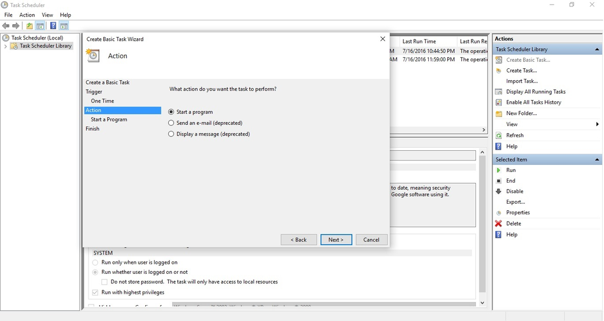

Now, a .bat file has to be created. It will be executed from command prompt in windows. The analog of this .bat file in Linux is .sh. Write the following lines of code in a notepad file:

**`@echo off`**

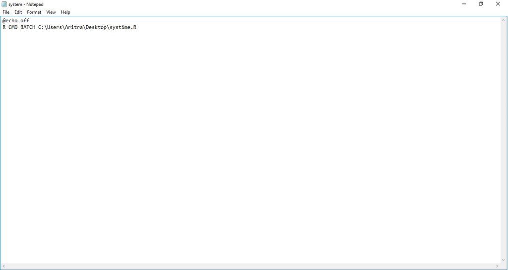

In task scheduler, **Browse the .bat file** in the field of Program Script. Click Next.

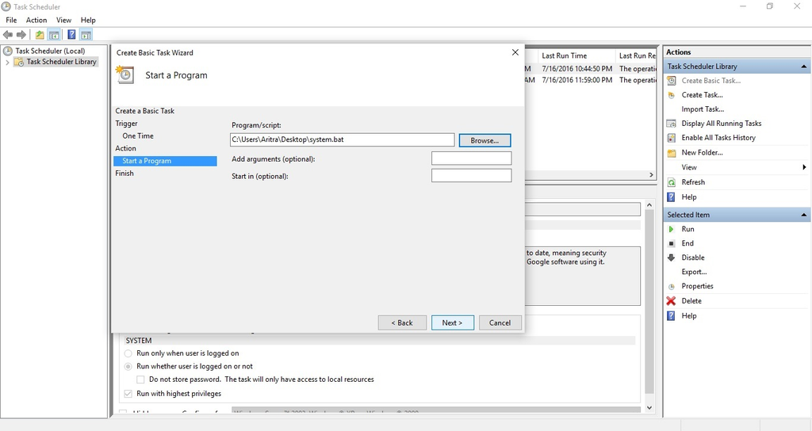

**Check in Open the Properties dialog**. Click on Finish.

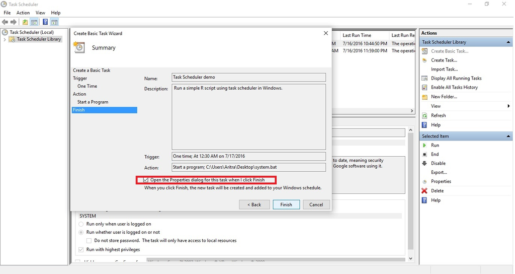

Under General tab, **check in Run with highest priviliges**.

Using sudo (in Linux) or running with highest privileges (in windows) is important in this case because it will allow r script to write data. If highest privilege is not grander saving the data file may be disrupted.

[figure not shown]

**Change and shift to Triggers tab. Select task and click on edit.**

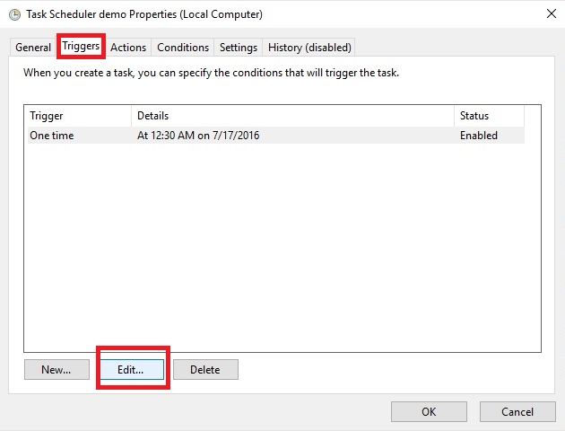

Check in Repeat task every and select duration. When you click on a time lag then you can simply change the value from keyboard. This will enable to execute task at and given time. Further options such as Expire can be edited if required. If not, simply click on OK.

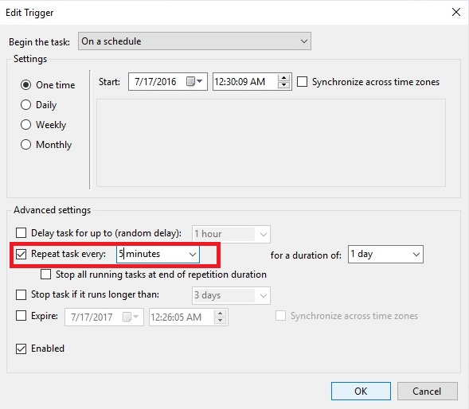

This .csv file will be generated in the directory of r script.

[figure not shown]

This .Rout file will be generated in the same directory. This will contain all the text printed in the R terminal.

[figure not shown]

### For Linux:

Now here we will create the same thing in a Linux environment on raspberry pi. The OS in this device is Debian Jessie. In order to run R script in this device we need to create a .sh file which will contain the bash or terminal script to run R script. At first create the systime.R file as mentioned earlier.

**Creating a shell executable script:**

Now save this file to into a location. Note down the path. This will be required later. I’ve save my file on Desktop. Now open terminal, change directory using cd. In my case,

**`cd Desktop`**

Now, open a text editor. I’m going to use Leaf pad, which comes pre-installed with raspbian. Type the following line of codes:

**`#! /bin/bash`**

**`R CMD BATCH /home/pi/Desktop/systime.R`**

and save this file as systime.sh.

**Changing permission:**

Now, make the .sh file executable by executing the following command from terminal

**`sudo chmod +x systime.sh`**

or simple right click on the script and go to **Properties -> Permissions -> Allow executing file as program**.

To verify the script is running simply click on the .sh file. The script should be executed and the .csv and .Rout file should be generated.

**Using crontab:**

As task scheduler in windows, Linux has its own version of called crontab. To run it use the following command in terminal:

**`sudo crontab -e`**

If crontab is running for the first time, choose nano to edit the file. Add the following lines of code at the end of the file. # at the beginning of a line means that the line is commented out. Those lines will not be executed. Do not put # in front of the line.

**`* * * * * /home/pi/Desktop/systime.sh`**

This line will direct the operating system to run the .sh file after every one minute. There is a option to change this duration. To see how to change this time duration in crontab simply read the commented out lines printed in the terminal.

After the required changes save it using Ctrl+X. Choose Yes, to save changes.

Now the R script should run from terminal and the latest run time of the script should be saved in a .csv file and as well as in the .Rout file in the selected directory.

**Application:**

Here I’ve used `get_video_data()` from the YouTubeR package to track the change in video statistics. What the function does is it downloads the data related to a video in a give period of time. Here I’m tracking videos posted in Times Now’s News hour debate on 12nd July. Here I’ve successfully obtained the change in viewCount, likeCount, dislikeCount and commentCount for two videos posted in the channel on above mentioned date in 5 mins interval from 10 A.M..

Here what the data looks like:

| items.id | items.snippet.title | items.snippet.channelTitle | items.statistics.viewCount | items.statistics.likeCount | items.statistics.dislikeCount | items.statistics.commentCount | time |
| --- | --- | --- | --- | --- | --- | --- | --- |
| e5MPn8q2v04 | Kashmir Clashes Due to Terrorist ‘Burhan Wani’s’ Death: The Newshour Debate (11th July 2016) | The Newshour Debate | 116 | 7 | 0 | 5 | 2016-07-12 09:55:01 |
| I9JBNpeNAhE | Hafiz Saeed & Syed Salahuddin Hold Memorial for Burhan Wani: The Newshour Debate (11th July 2016) | The Newshour Debate | 113 | 7 | 1 | 5 | 2016-07-12 09:55:02 |
| e5MPn8q2v04 | Kashmir Clashes Due to Terrorist ‘Burhan Wani’s’ Death: The Newshour Debate (11th July 2016) | The Newshour Debate | 124 | 9 | 0 | 6 | 2016-07-12 10:00:03 |
| I9JBNpeNAhE | Hafiz Saeed & Syed Salahuddin Hold Memorial for Burhan Wani: The Newshour Debate (11th July 2016) | The Newshour Debate | 116 | 8 | 1 | 6 | 2016-07-12 10:00:03 |

**Visualization:**

Here, viewCount, likeCount, dislikeCount and commentCount has been plotted against time. The x-axis and y-axis represents time and count respectively. It shows change in count over time.

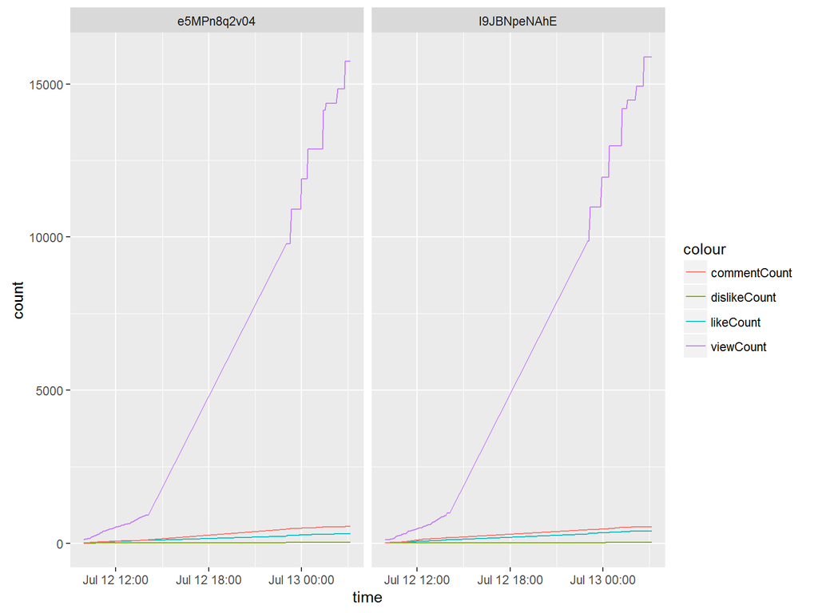

**Fitting a linear model:**

Here, we are fitting a LM on viewCount w.r.t time. **Time=Current time-Published.At** . Model does not fits the data well because of non-linearity, but it definitely shows the way forward.

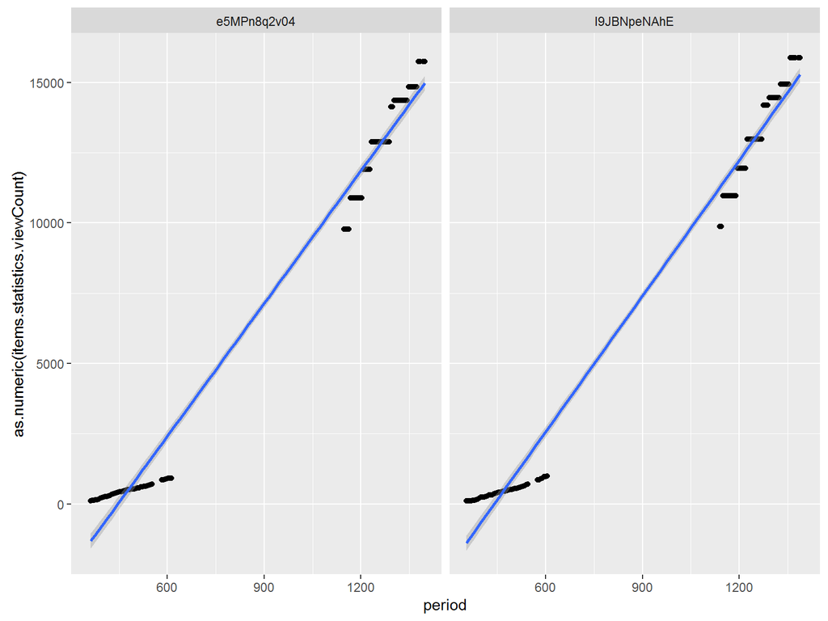

**Note:**

My computer was turned off during 2PM to 11PM on that day that’s why there a jump in the graph at the same time. This can be considered as a reminder that in order to obtain data continuously **one must turn on a computer for a cetain period of time**. It is true for internet connectivity as well depending on the requirement of the program.

This is just a simple example of where crontab can be used. There are many more things can be done using crontab, shiny and R. I’m going to present some examples related this topic and shiny soon.

The source code for this is available in [here](https://github.com/AritraBiswas/Taskscheduler-and-Crontab-with-R) and a slider version of this presentation is available [here](http://rpubs.com/itheta/197285).